# Hadoop Popularity

Keith Hultman

September 25, 2016

## Exploring the popularity of Pig and Hive

Pig and Hive are sometimes compared with one another for their ability to do data manipulations on a Hadoop cluster. There are some important differences. Hive is a direct implementation of the SQL language standard, which gives it a leg-up in terms of user familiarity. I wanted to see how the two compared in the number of posts on [Stack Overflow](http://stackoverflow.com/) a popular question/answer site for software developers.

I first found the most popular tag for the associated technologies at [Stackoverflow](http://stackoverflow.com/tags). Then I used the public data explorer on [StackExchange](http://data.stackexchange.com/stackoverflow/query/440749/anonymous-feedback-votes-over-time-on-a-specific-tag?tagname=ocaml&ref=survey-2016#graph) and entered the tags as queries. I then downloaded the csv file and brought it in to R for some visualizations.

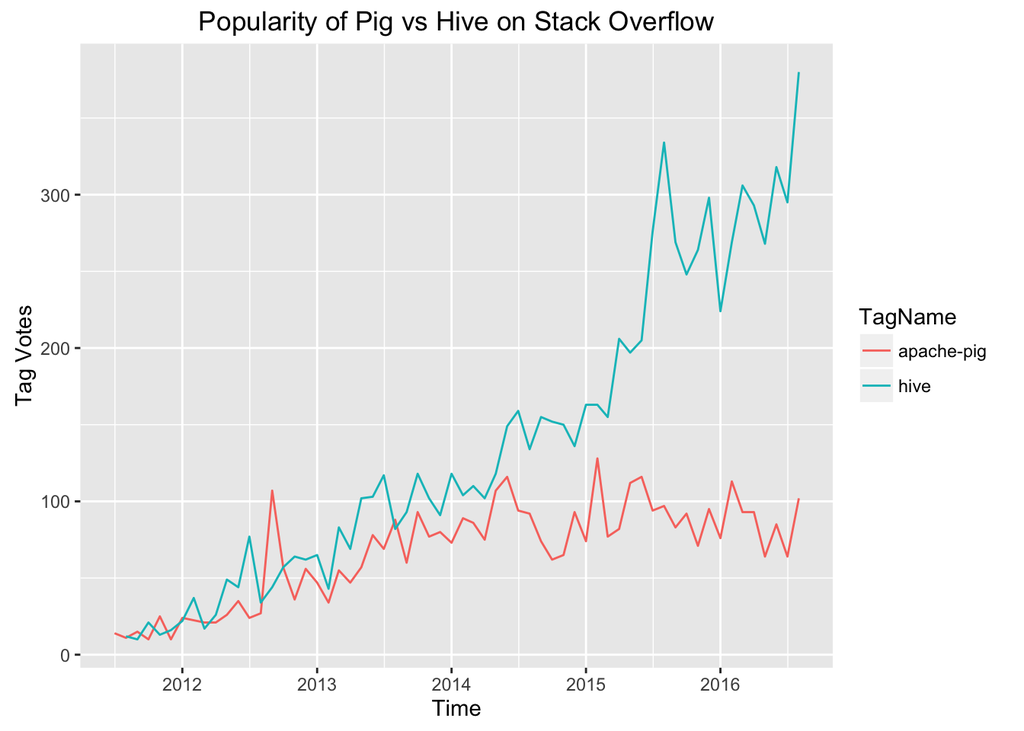

```r
pig <- read.csv("pig.csv", header = TRUE)
hive <- read.csv("hive.csv", header = TRUE)
pighive <- rbind(pig, hive) #combine the data to one dataframe
pighive$mo <- strptime(x = as.character(pighive$mo), format = "%Y-%m-%d %H:%M:%S")

ggplot(pighive, aes(mo, Total.Votes)) +
  geom_line(aes(color = TagName)) +
  ggtitle("Popularity of Pig vs Hive on Stack Overflow") +
  ylab("Tag Votes") +
  xlab("Time")
```

## A comparison of all Hadoop-related technology popularity

How do the other Hadoop-related technologies compare?

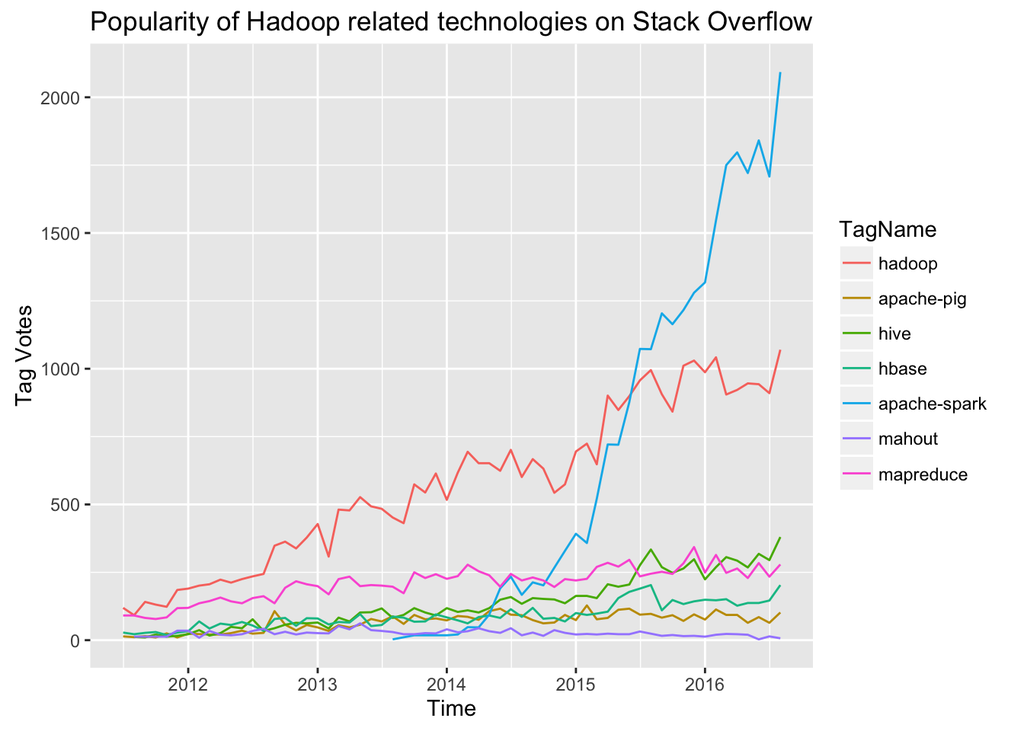

```r
hadoop <- read.csv("hadoop.csv", header = TRUE)
hbase <- read.csv("hbase.csv", header = TRUE)
spark <- read.csv("spark.csv", header = TRUE)
mahout <- read.csv("mahout.csv", header = TRUE)
mapreduce <- read.csv("mapreduce.csv", header = TRUE)

hadoop_all <- rbind(hadoop, pig, hive, hbase, spark, mahout, mapreduce) #combine the data to one dataframe
hadoop_all$mo <- strptime(x = as.character(hadoop_all$mo), format = "%Y-%m-%d %H:%M:%S")

ggplot(hadoop_all, aes(mo, Total.Votes)) +
  geom_line(aes(color = TagName)) +
  ggtitle("Popularity of Hadoop related technologies on Stack Overflow") +
  ylab("Tag Votes") +
  xlab("Time")
```

Hive’s rise is completely dwarfed by the acceleration over the past year and half of Spark. Spark is tagged in twice the number of posts as the general Hadoop tag, a technology it was built upon. This has convinced me to put full effort into learning Spark going forward.